# mlproject

Scott Wilson

May 1, 2016

## Data Analysis

The purpose of this project is to use some wearable data created by exercisers to predict, based on this data, how well they did their exercises. The data comes from http://groupware.les.inf.puc-rio.br/har who contributed it for our use. We have pre-downloaded training and test datasets, and have them available locally.

The variable we wish to predict is “classe”, which indicates how the exercise was performed - either free or error or with a particular type of error. According to the dataset description, possible values of this column are:

- exactly according to the specification (Class A),
- throwing the elbows to the front (Class B),
- lifting the dumbbell only halfway (Class C),
- lowering the dumbbell only halfway (Class D) and
- throwing the hips to the front (Class E).

Let’s read the data in and remove the zero variance information, the first 7 columns, then the columns where more than three quarters are NA. None of this has predictive value.

```r
training <- read.csv("./pml-training.csv")
testing <- read.csv("./pml-testing.csv")
myTraining <- training
nz <- nearZeroVar(training,saveMetrics=TRUE)
myTraining <- myTraining[,nz$nzv==FALSE]
myTraining <- myTraining[,-c(1:7)]

badc <- NULL
for (i in 1:length(myTraining)) {
  if (sum(is.na(myTraining[,i]))/nrow(myTraining) > 0.75) {
    badc <- c(badc,i)
  }
}
myTraining <- myTraining[,-badc]
```

We want to run a random forest, but we want it to terminate in reasonable time. Let’s use 10 trees. (Note: to answer the quiz question, I used a 50 tree model, and got a perfect score, so I didn’t want to increase the number of trees. The default number of trees runs for several hours.)

```r
model <- train(classe ~ ., data=myTraining,ntree=10)
prediction <- predict(model, myTraining)
confusionMatrix(prediction, training$classe)
```

```
## Confusion Matrix and Statistics
##
##           Reference
## Prediction    A    B    C    D    E
##          A 5579    1    0    0    0
##          B    1 3796    0    0    0
##          C    0    0 3422    3    0
##          D    0    0    0 3213    0
##          E    0    0    0    0 3607
##
## Overall Statistics
##
##                Accuracy : 0.9997
##                  95% CI : (0.9994, 0.9999)
##     No Information Rate : 0.2844
##     P-Value [Acc > NIR] : < 2.2e-16
##
##                   Kappa : 0.9997
##  Mcnemar's Test P-Value : NA
##
## Statistics by Class:
##
##                      Class: A Class: B Class: C Class: D Class: E
## Sensitivity            0.9998   0.9997   1.0000   0.9991   1.0000
## Specificity            0.9999   0.9999   0.9998   1.0000   1.0000
## Pos Pred Value         0.9998   0.9997   0.9991   1.0000   1.0000
## Neg Pred Value         0.9999   0.9999   1.0000   0.9998   1.0000
## Prevalence             0.2844   0.1935   0.1744   0.1639   0.1838
## Detection Rate         0.2843   0.1935   0.1744   0.1637   0.1838
## Detection Prevalence   0.2844   0.1935   0.1745   0.1637   0.1838
## Balanced Accuracy      0.9999   0.9998   0.9999   0.9995   1.0000
```

So this looks pretty accurate.

## Diagram

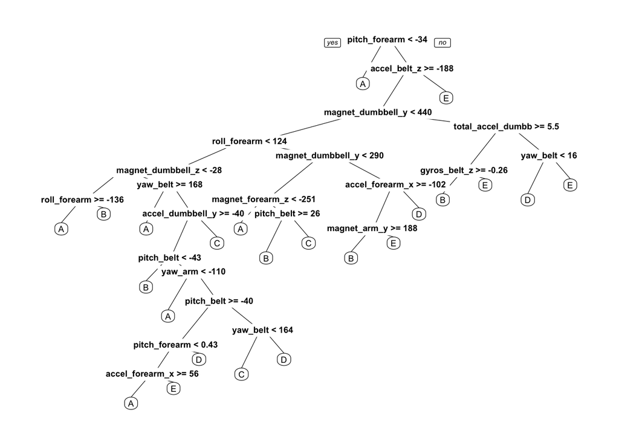

```r
tree <- rpart(classe~.,data=myTraining, method="class")
prp(tree)
```

## References

Ugulino, W.; Cardador, D.; Vega, K.; Velloso, E.; Milidiu, R.; Fuks, H. Wearable Computing: Accelerometers’ Data Classification of Body Postures and Movements. Proceedings of 21st Brazilian Symposium on Artificial Intelligence. Advances in Artificial Intelligence - SBIA 2012. In: Lecture Notes in Computer Science. , pp. 52-61. Curitiba, PR: Springer Berlin / Heidelberg, 2012. ISBN 978-3-642-34458-9. DOI: 10.1007/978-3-642-34459-6_6.